# Pruebas de hipótesis para proporciones sobre datos geo-referenciados de El Salvador

DataIntelligence

04-06-2020

#### Introducción:

Tenemos un conjunto de 527575 observaciones agrupadas en cuatro categorías:

1. Bosque Bosque
2. Bosque no Bosque
3. No Bosque Bosque
4. No Bosque no Bosque

Deseamos optimizar la información de la población extrayendo una muestra representativa que mantenga las proporciones de las categorías a cierto nivel de significación, digamos, con un 99% de certeza.

Nuestra hipótesis nula será que la muestra que extraemos contendrá las mismas proporciones que la población con un nivel de significación estadístico.

Por el caracter experimental de las pruebas de hipótesis, no se puede determinar un tamaño muestral óptimo n, sin embargo, estimaremos su tamaño inicial graficando el momento en el que el tamaño de las muestras excede el valor límite asociado al nivel de significación (y por lo tanto rechazamos nuestra hipótesis nula).

Las pruebas de hipótesis son experimentos, por lo que la solución es un problema eminentemente empirico.

```r
# Leemos los datos, construímos un dataframe y obtenemos el número de observaciones:
data <- read_excel("datos salvador.xlsx")
data <- data.frame(data)
nrow(data)
```

```
## [1] 527575
```

```r
# Obtenemos el nombre de las columnas del dataset  que cargamos:
colnames(data)
```

```
## [1] "OBJECTID"      "SAMPLE_ID"     "PLOT_ID"       "LON"
## [5] "LAT"           "ClaveCob1Cob2"
```

```r
## Obtenemos las categorias y las frecuencias de la variable nominal "ClaveCob1Cob2":
count(data, 'ClaveCob1Cob2')
```

```
##        ClaveCob1Cob2   freq
## 1       BosqueBosque 158729
## 2    BosqueNo Bosque  15397
## 3    No BosqueBosque  16901
## 4 No BosqueNo Bosque 336548
```

```r
prop.table(table(data$ClaveCob1Cob2))
```

```
##
##       BosqueBosque    BosqueNo Bosque    No BosqueBosque No BosqueNo Bosque
##         0.30086528         0.02918448         0.03203526         0.63791499
```

```r
## Obtenemos los porcentajes
prop.table(table(data$ClaveCob1Cob2))*100
```

```
##
##       BosqueBosque    BosqueNo Bosque    No BosqueBosque No BosqueNo Bosque
##          30.086528           2.918448           3.203526          63.791499
```

El problema de investigación es encontrar una muestra aleatoria que satisfaga estas cuatro proporciones simultáneamente utilizando un criterio estadístico con una significación del 99%.

#### Hipótesis estadísticas:

$H_0:$ Las categorías de nuestra muestra se distribuyen en la misma proporción que la población con un nivel de significación del 99%.

#### Valor del $\alpha =$ 0.01 para dos colas:

```r
alpha = .01
z.half.alpha = qnorm(1-alpha / 2)
c(-z.half.alpha , z.half.alpha)
```

```
## [1] -2.575829  2.575829
```

#### Cálculo del estadístico p-value:

Como ejercicio consideremos una muestra que sea el total de la poblacion y apliquemos el estadistico p-value. Observaremos que éste tiende a 0 para todas las categorías (y no es cero exacto por el problema del redondeo computacional).

$Z=\frac{{\hat{p}}-{p}_{0}}{\sqrt{\frac{{p}_{0}(1-{p}_{0})}{n}}}$

#### Muestra igual a la poblacion total:

```r
data_m <- data[sample(NROW(data), NROW(data)*(1 - 0)),]
n = nrow(data_m)
n
```

```
## [1] 527575
```

```r
head(data_m,10)
```

```
##        OBJECTID SAMPLE_ID PLOT_ID       LON      LAT      ClaveCob1Cob2
## 306806   306806         8    6860 -89.06371 13.66791 No BosqueNo Bosque
## 78376     78376        16    4040 -89.66831 14.04129 No BosqueNo Bosque
## 111947   111947        12    8535 -89.14023 13.96534 No BosqueNo Bosque
## 439661   439661        16   17567 -87.98099 13.43924    BosqueNo Bosque
## 6972       6972        17    5142 -89.42186 14.36022    BosqueNo Bosque
## 473338   473338         3   14121 -88.50730 13.35553 No BosqueNo Bosque
## 500991   500991        21   13879 -88.33094 13.27491 No BosqueNo Bosque
## 466118   466118         3   17147 -87.93494 13.37638 No BosqueNo Bosque
## 304918   304918        13   12136 -88.65694 13.67096 No BosqueNo Bosque
## 2582       2582        12    5232 -89.47798 14.39578       BosqueBosque
```

```r
pbar = prop.table(table(data_m$ClaveCob1Cob2))
pbar
```

```
##
##       BosqueBosque    BosqueNo Bosque    No BosqueBosque No BosqueNo Bosque
##         0.30086528         0.02918448         0.03203526         0.63791499
```

```r
#pbar[1]

p0_BB = 0.30086528 # constante
p0_BNoB = 0.02918448
p0_NoBB = 0.03203526
p0_NoBNoB = 0.63791499

z_BB = (pbar[1] - p0_BB)/sqrt(p0_BB*(1-p0_BB)/n)
z_BNoB = (pbar[2] - p0_BNoB)/sqrt(p0_BNoB*(1-p0_BNoB)/n)
z_NoBB = (pbar[3] - p0_NoBB)/sqrt(p0_NoBB*(1-p0_NoBB)/n)
z_NoBNoB = (pbar[4] - p0_NoBNoB)/sqrt(p0_NoBNoB*(1-p0_NoBNoB)/n)
```

Observamos que el estadistico p-value tiende a cero:

```r
z_BB
```

```
##  BosqueBosque
## -2.881792e-07
```

```r
z_BNoB
```

```
## BosqueNo Bosque
##   -1.665296e-05
```

```r
z_NoBB
```

```
## No BosqueBosque
##   -1.793916e-05
```

```r
z_NoBNoB
```

```
## No BosqueNo Bosque
##      -2.432802e-06
```

Mientras menor sea la muestra cada vez será mayor el estadístico p-value hasta que alcance el valor limite para alpha = .01, z = [-2.575829; 2.575829]

Como hemos señalado, no puede ser aslcanzado un tamaño muestral óptimo por la naturaleza aleatoria de la extraccion, cada vez dará un p-value distinto aunque aproximado a medida que aumenta el tamaño muestral.

Podemos creer que una muestra de 500 es aproximadamente siempre válida:

```r
data_sub_m <- data[sample(NROW(data), NROW(data)*(1 - 0.99905)),]

tamanio_subdata = nrow(data_sub_m)
tamanio_subdata
```

```
## [1] 501
```

```r
head(data_sub_m,10)
```

```
##        OBJECTID SAMPLE_ID PLOT_ID       LON      LAT      ClaveCob1Cob2
## 83593     83593        13    8908 -88.99274 14.02998 No BosqueNo Bosque
## 481005   481005        25   16879 -87.98042 13.33124       BosqueBosque
## 336061   336061        16     649 -89.85750 13.62365       BosqueBosque
## 487149   487149         8   16787 -87.74992 13.31370       BosqueBosque
## 364592   364592         7   14839 -88.57327 13.58099 No BosqueNo Bosque
## 402660   402660         5    5978 -89.20103 13.51336 No BosqueNo Bosque
## 113112   113112        12    8514 -89.33451 13.96355 No BosqueNo Bosque
## 176905   176905        10    2598 -89.45375 13.85433 No BosqueNo Bosque
## 471572   471572        22   17005 -88.24830 13.35682 No BosqueNo Bosque
## 71578     71578        23    4126 -89.83493 14.05770       BosqueBosque
```

```r
pbar = prop.table(table(data_sub_m$ClaveCob1Cob2))
pbar
```

```
##
##       BosqueBosque    BosqueNo Bosque    No BosqueBosque No BosqueNo Bosque
##         0.32335329         0.03592814         0.04391218         0.59680639
```

```r
z_BB = (pbar[1] - p0_BB)/sqrt(p0_BB*(1-p0_BB)/tamanio_subdata)
z_BNoB = (pbar[2] - p0_BNoB)/sqrt(p0_BNoB*(1-p0_BNoB)/tamanio_subdata)
z_NoBB = (pbar[3] - p0_NoBB)/sqrt(p0_NoBB*(1-p0_NoBB)/tamanio_subdata)
z_NoBNoB = (pbar[4] - p0_NoBNoB)/sqrt(p0_NoBNoB*(1-p0_NoBNoB)/tamanio_subdata)

z_BB
```

```
## BosqueBosque
##     1.097497
```

```r
z_BNoB
```

```
## BosqueNo Bosque
##        0.896748
```

```r
z_NoBB
```

```
## No BosqueBosque
##        1.509658
```

```r
z_NoBNoB
```

```
## No BosqueNo Bosque
##          -1.914542
```

Grafiquemos los p_value para cada una de nuestras categorías para determinar cuando se acerca al valor límite en el que se rechaza la hipótesis nula (línea punteada roja).

```r
# bosque a bosque
z_BB
```

```
## BosqueBosque
##     1.097497
```

### Grafica de los p_values:

```r
my_seq <- seq(0.01, 0.5, by=0.01)
# my_seq <- seq(1, 527575, by=1)
# my_seq <- seq(1, 527575, by=1000)
z_Bos_Bos <- c()
z_Bos_no_Bos <- c()
z_No_Bos_Bos <- c()
z_No_Bos_no_Bos <- c()
muestras_decrecientes <- data[sample(NROW(data), NROW(data)*(1 - 0)),]
# muestras_decrecientes
for (i in my_seq)
{
# aca ocurre un efecto: mientras mas pequena es la muestra, mayor es la tajada que se extrae
        muestras_decrecientes <- muestras_decrecientes[sample(NROW(muestras_decrecientes), NROW(muestras_decrecientes)*(1 - i)),]

        # muestras_decrecientes <- muestras_decrecientes[-sample(i)]

        n_row = nrow(muestras_decrecientes)

        pbar = prop.table(table(muestras_decrecientes$ClaveCob1Cob2))

        z_Bosque_Bosque = (pbar[1] - p0_BB)/sqrt(p0_BB*(1-p0_BB)/n_row)
        z_Bos_Bos <- append(z_Bos_Bos, z_Bosque_Bosque)

        z_Bosque_no_Bosque = (pbar[2] - p0_BNoB)/sqrt(p0_BNoB*(1-p0_BNoB)/n_row)
        z_Bos_no_Bos <- append(z_Bos_no_Bos, z_Bosque_no_Bosque)

        z_No_Bosque_Bosque = (pbar[3] - p0_NoBB)/sqrt(p0_NoBB*(1-p0_NoBB)/n_row)
        z_No_Bos_Bos <- append(z_No_Bos_Bos, z_No_Bosque_Bosque)

        z_No_Bosque_no_Bosque = (pbar[4] - p0_NoBNoB)/sqrt(p0_NoBNoB*(1-p0_NoBNoB)/n_row)
        z_No_Bos_no_Bos <- append(z_No_Bos_no_Bos, z_No_Bosque_no_Bosque)

}


# Gráfica del p-value para Bosque Bosque

z_Bos_Bos
```

```
##       BosqueBosque       BosqueBosque       BosqueBosque       BosqueBosque
##         0.25151177         0.30538328         0.40007716         0.24468325
##       BosqueBosque       BosqueBosque       BosqueBosque       BosqueBosque
##         0.75075481         0.47091536         0.36106502         0.54914883
##       BosqueBosque       BosqueBosque       BosqueBosque       BosqueBosque
##         0.79973825         0.52230747        -0.04691933        -0.16838112
##       BosqueBosque       BosqueBosque       BosqueBosque       BosqueBosque
##         0.32576041        -0.49770611        -0.38265941        -0.85842053
##       BosqueBosque       BosqueBosque       BosqueBosque       BosqueBosque
##        -0.19322102        -0.12111047        -0.14235688         1.17556699
##       BosqueBosque       BosqueBosque       BosqueBosque       BosqueBosque
##         1.68965977         1.36586893         1.51270152         1.09321186
##       BosqueBosque       BosqueBosque       BosqueBosque       BosqueBosque
##         2.05932001         1.73633932         1.17564235         1.33529855
##       BosqueBosque       BosqueBosque       BosqueBosque       BosqueBosque
##         1.31788113         0.80141555        -0.09382538         1.01707811
##       BosqueBosque       BosqueBosque       BosqueBosque       BosqueBosque
##         0.45847336         0.89254476        -0.01487094         0.51141432
##       BosqueBosque       BosqueBosque       BosqueBosque       BosqueBosque
##        -0.63645361        -0.64158268        -1.27408299        -1.95545377
##       BosqueBosque       BosqueBosque No BosqueNo Bosque No BosqueNo Bosque
##        -1.47108521        -1.51830336         3.73396312         2.64031064
## No BosqueNo Bosque
##         1.52438406                 NA                 NA                 NA
##
##                 NA                 NA
```

```r
head(z_Bos_Bos,10)
```

```
## BosqueBosque BosqueBosque BosqueBosque BosqueBosque BosqueBosque BosqueBosque
##    0.2515118    0.3053833    0.4000772    0.2446833    0.7507548    0.4709154
## BosqueBosque BosqueBosque BosqueBosque BosqueBosque
##    0.3610650    0.5491488    0.7997382    0.5223075
```

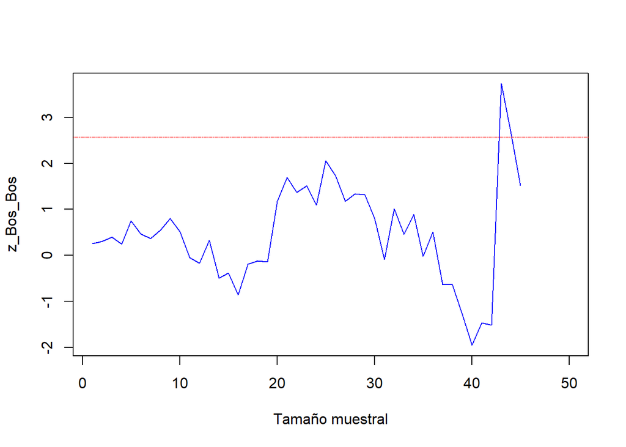

```r
plot(z_Bos_Bos, type="l", col="blue", lwd=1, xlab="Tamaño muestral")
abline(h=-2.575829, col="red", lwd=0.5, lty=6)
abline(h=2.575829, col="red", lwd=0.5, lty=6)
```

```r
# Gráfica del p-value para Bosque no Bosque

head(z_Bos_no_Bos,10)
```

```
## BosqueNo Bosque BosqueNo Bosque BosqueNo Bosque BosqueNo Bosque BosqueNo Bosque
##       0.1313241       0.3806214       0.4889615       0.5730816       0.6897168
## BosqueNo Bosque BosqueNo Bosque BosqueNo Bosque BosqueNo Bosque BosqueNo Bosque
##       0.7470229       0.6948514       0.5296476       0.6537836       0.8759688
```

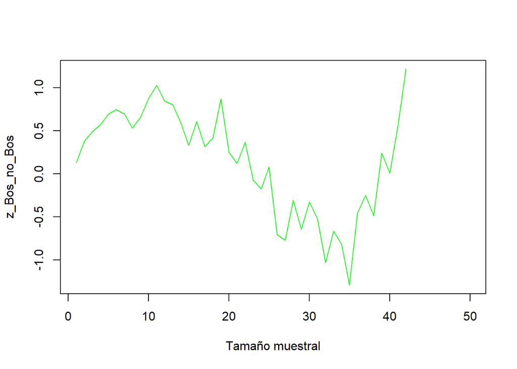

```r
plot(z_Bos_no_Bos, type="l", col="green", lwd=1, xlab="Tamaño muestral")
abline(h=-2.575829, col="red", lwd=0.5, lty=6)
abline(h=2.575829, col="red", lwd=0.5, lty=6)
```

```r
# Gráfica del p-value para No Bosque Bosque

head(z_No_Bos_Bos,10)
```

```
## No BosqueBosque No BosqueBosque No BosqueBosque No BosqueBosque No BosqueBosque
##      0.03941226      0.04489497     -0.14837578      0.03133733     -0.05676115
## No BosqueBosque No BosqueBosque No BosqueBosque No BosqueBosque No BosqueBosque
##     -0.22074196      0.16364736     -0.13528905      0.04548534     -0.15327603
```

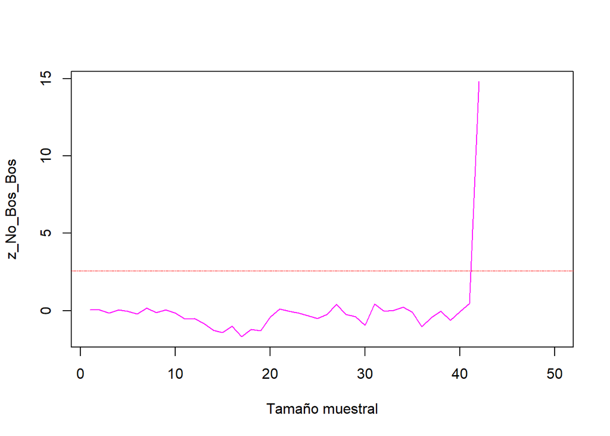

```r
plot(z_No_Bos_Bos, type="l", col="magenta", lwd=1, xlab="Tamaño muestral")
abline(h=-2.575829, col="red", lwd=0.5, lty=6)
abline(h=2.575829, col="red", lwd=0.5, lty=6)
```

```r
# Gráfica del p-value para No Bosque no Bosque
head(z_No_Bos_no_Bos,10)
```

```
## No BosqueNo Bosque No BosqueNo Bosque No BosqueNo Bosque No BosqueNo Bosque
##         -0.3004647         -0.4411946         -0.4986894         -0.4457073
## No BosqueNo Bosque No BosqueNo Bosque No BosqueNo Bosque No BosqueNo Bosque
##         -0.9372154         -0.6301551         -0.6478942         -0.6599893
## No BosqueNo Bosque No BosqueNo Bosque
##         -1.0088360         -0.7490765
```

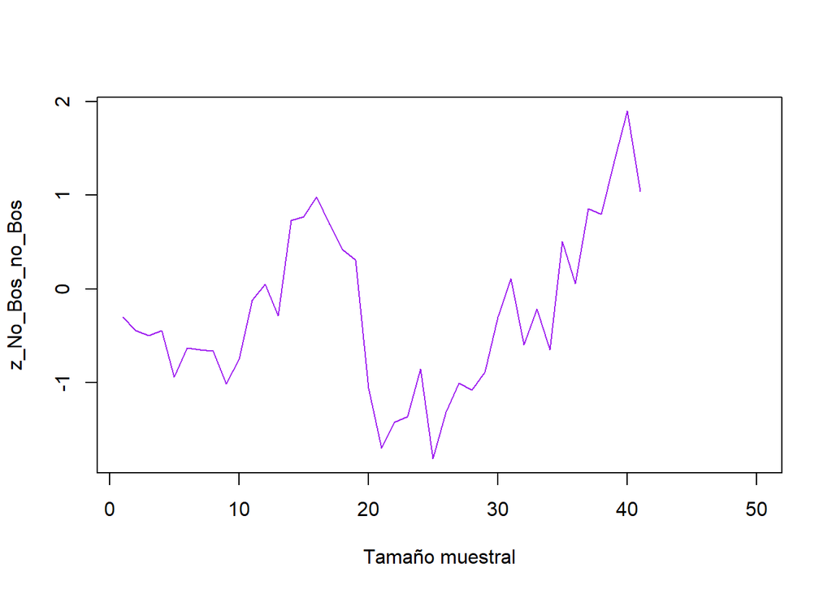

```r
plot(z_No_Bos_no_Bos, type="l", col="purple", lwd=1, xlab="Tamaño muestral")
abline(h=-2.575829, col="red", lwd=0.5, lty=6)
abline(h=2.575829, col="red", lwd=0.5, lty=6)
```

#### Conclusión

Podemos extraer una muestra inicial con el 60% de la población y aplicarle el test estadístico p-value para corroborar que ésta muestra específica sea representativa de la población.

```r
#
muestras_decrecientes
```

```
## [1] OBJECTID      SAMPLE_ID     PLOT_ID       LON           LAT
## [6] ClaveCob1Cob2
## <0 rows> (or 0-length row.names)
```

```r
#
```